# Exercise II - Correlation Only (25 Questions)

## EVALUATE LEVEL (4 vragen)

### Vraag Q21 (Evaluate)

**Two criminology studies show conflicting results about the relationship between poverty and crime rates. Study A (N=50) reports r = 0.72, p < 0.001. Study B (N=5000) reports r = 0.18, p < 0.001. Which study provides more trustworthy evidence?**

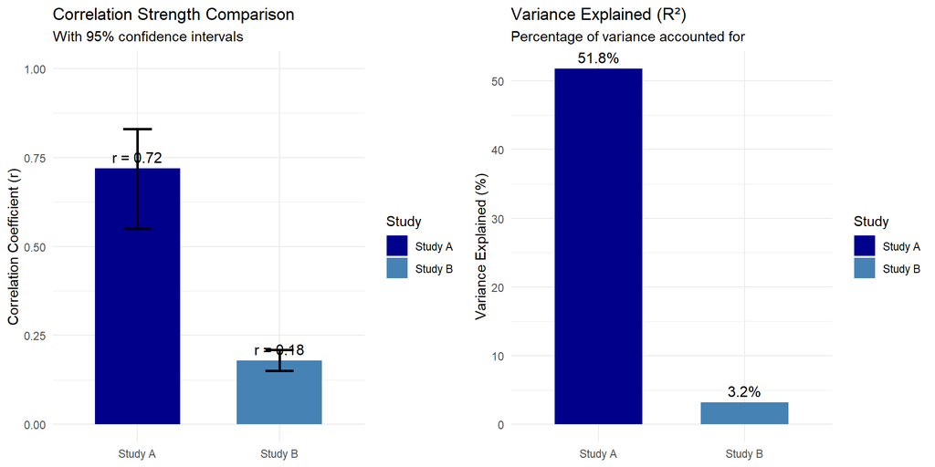

**Critical Evaluation Factors:** 1. Study B has a much larger sample size (5000 vs 50) 2. Study A shows a much stronger effect (r = 0.72 vs r = 0.18) 3. Both are statistically significant (p < 0.001) 4. Study A explains 51.8% of variance vs. only 3.2% in Study B 5. Study B likely offers better external validity due to larger, more representative sample

> **Hint:** Consider sample size, effect size, statistical significance, and practical significance.
1. Study A because it has a stronger correlation  
   “1” = “❌ Incorrect. While Study A shows a stronger correlation (r = 0.72 vs r = 0.18), correlation strength alone doesn’t determine trustworthiness. The small sample size (N=50) in Study A is problematic because small samples are more vulnerable to sampling error and can produce unstable, unreliable estimates. In criminological research, strong correlations from small samples often fail to replicate in larger, more representative samples. This pattern is called the ‘decline effect’ — impressive initial findings that diminish when studied more rigorously. Additionally, small samples can be unduly influenced by a few extreme cases or selection bias. The seemingly impressive correlation in Study A should be viewed with appropriate skepticism.”
2. Study B because of the much larger sample size providing more reliable estimates  
   “2” = “✅ Correct! Large N gives more stable, generalizable estimates despite smaller effect. Study B’s sample size (N=5000) provides much greater statistical power and precision. With such a large sample, even small correlations like r = 0.18 can be reliable and meaningful in criminological contexts. The 95% confidence interval around this estimate will be much narrower than for Study A, indicating greater precision. Furthermore, large samples are more likely to represent the true population diversity, reducing selection bias. In criminology, where policy decisions affect many lives, we should prioritize large, representative samples over impressive-looking correlations from small studies. Study B likely captures the true relationship between poverty and crime more accurately, even though the effect appears smaller.”
3. Both are equally valid since both are statistically significant  
   “3” = “❌ Incorrect. Statistical significance doesn’t guarantee practical importance or reliability. While both studies show p < 0.001, this only tells us the results are unlikely due to random chance — it says nothing about the quality of sampling, measurement, or generalizability. In criminological research, it’s relatively easy to achieve statistical significance with poor methodology, especially in small samples with large effects (Study A) or large samples with small effects (Study B). The fact that both are ‘significant’ tells us little about their relative trustworthiness. Statistical significance should never be the sole criterion for evaluating evidence quality. Instead, methodological rigor, sample representativeness, and replicability are far more important considerations.”
4. Neither because correlational studies can’t establish causation  
   “4” = “❌ Incorrect. While true about causation, the question asks about trustworthy evidence for the relationship strength. Both studies provide evidence about the association between poverty and crime, even if they can’t definitively establish causation. In criminology, correlational evidence is still valuable for understanding patterns and generating hypotheses, particularly when experimental designs are impractical or unethical (we can’t randomly assign people to poverty conditions). The limitation regarding causation applies equally to both studies and doesn’t help us evaluate which provides more trustworthy evidence about the strength of the relationship. Study B’s large sample still makes it more trustworthy for estimating the correlation magnitude, regardless of causal implications.”

### Vraag Q22 (Evaluate)

**A news article claims: “Strong correlation (r = 0.65) between neighborhood watch programs and reduced burglary proves these programs are highly effective crime prevention tools.” Evaluate this statistical claim.**

> **Hint:** Consider correlation vs. causation, confounding variables, and research design limitations.
1. Valid conclusion - strong correlation provides sufficient evidence of effectiveness  
   “1” = “❌ Incorrect. Correlation alone cannot establish causal effectiveness. Even a strong correlation coefficient (r = 0.65) only tells us the variables are associated, not that one causes the other. For instance, neighborhoods with stronger community cohesion might independently have both more neighborhood watch participation AND lower crime rates due to informal social control. In criminology, policy recommendations require stronger causal evidence than mere correlation, typically from experimental or quasi-experimental designs (like randomized controlled trials or regression discontinuity). The news article makes a fundamental error in statistical interpretation that could lead to misallocated crime prevention resources.”
2. Invalid - correlation doesn’t prove causation; neighborhood characteristics might explain both variables  
   “2” = “✅ Correct! Confounders like socioeconomic status could influence both program presence and crime rates. This is a classic example of potential confounding in criminological research. Wealthier neighborhoods often have both more resources to establish watch programs AND lower baseline crime rates. Other possible confounders include: population density, residential stability, police presence, or architectural features. Without controlling for these variables using methods like multiple regression or propensity score matching, we cannot attribute crime reduction to the watch programs. Additionally, the direction of causality could be reversed—neighborhoods with lower crime rates might have more residents willing to participate in watch programs, rather than the programs causing the lower crime.”
3. Invalid - r = 0.65 is too weak to support any conclusions  
   “3” = “❌ Incorrect. The correlation strength isn’t the main issue; causation vs. correlation is. In fact, r = 0.65 would generally be considered a strong correlation in criminological research. The fundamental problem with the news article’s claim isn’t that the correlation is too weak, but that correlation—regardless of strength—cannot establish causation. Even a perfect correlation (r = 1.00) wouldn’t prove that neighborhood watch programs cause crime reduction. Evidence-based criminology requires distinguishing between correlation and causation through appropriate research methodology, including randomized trials, natural experiments, instrumental variables, or statistical controls for potential confounders.”
4. Valid if the sample size was large enough  
   “4” = “❌ Incorrect. Sample size doesn’t resolve the causation problem. A larger sample would increase statistical power and provide more precise correlation estimates, but it cannot transform a correlational finding into a causal one. The logical fallacy in the news article’s claim—that correlation implies causation—persists regardless of sample size. In criminological research, sample size matters for reliability and generalizability, but the research design determines whether causal claims are warranted. Without appropriate design features like randomization, time-order establishment, or control for confounding variables, even studies with enormous samples cannot support causal conclusions about program effectiveness.”